# Airline delay dataset exploration findings

## Ramanathan

## Investigation Overview

> It can be noted that least average flight delay happened on the year of 2020 and generally during the months of june and july the average flight delay time is maximum

> November month has the least amount of cancellations while january has the most flights cancelled

> Different carriers have varying total arrived flights, indicating differences in market share and scale. South west airlines has the most arrived flights.

## Dataset Overview

> This dataset is mainly focused on the various types of delays and the duration of these delay. it is an extensive database of over 20 years. Data is categorised based on the carrier,airport and carrier code.

## Average Flight Delay Over Time

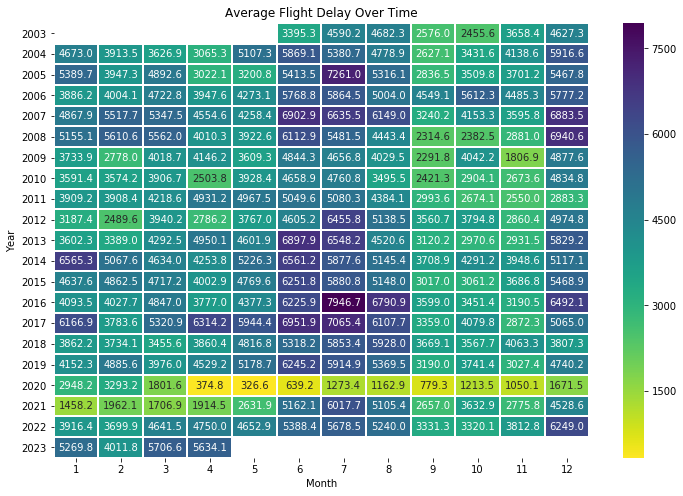

## Total cancelled Flights by month

> November month has the least amount of cancellations while january has the most flights cancelled

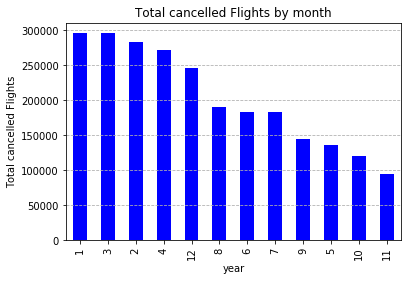

## Market share of different airlines

> Different carriers have varying total arrived flights, indicating differences in market share and scale. South west airlines has the most arrived flights.

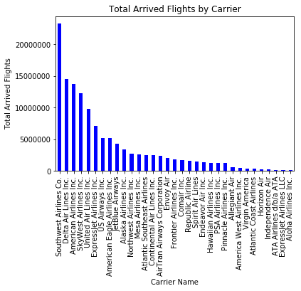